# UFO sightings

## Multi-witness prediction

I tried to assess if I am able to predict if a sighting is multi-witness sighting from the shape, length and the part of the day.

I grouped shapes to Vague/Detailed categories.

I trained a logistic regression model for the prediction, because it is more flexible with non-linear cyclic data - which we have now. The VIF values are great, so the data doesn’t show multicollinearity.

The coefficients are significant for Vague shapes, duration, and Evening - and with negative direction for Morning.

```r
# Create features
model_data <- ufo_clean %>%
  filter(!is.na(latitude), !is.na(longitude), !is.na(encounter_length), !is.na(ufo_shape)) %>%
  mutate(
    # Spatiotemporal bins (for finding neighbors)
    lat_bin = round(latitude, 1),
    lon_bin = round(longitude, 1),
    time_bin = round_date(date_time, unit = "1 hour"),

    # Shape grouping: Vague vs. Detailed
    is_detailed = ifelse(
      ufo_shape %in% c("triangle", "disk", "cigar", "formation", "diamond", "cylinder", "sphere", "oval"),
      "Detailed Structure",
      "Vague (Light/Flash)"
    ),

    # Log duration
    log_duration = log(encounter_length + 1)
  ) %>%

  # 4. Calculate cluster target
  group_by(lat_bin, lon_bin, time_bin) %>%
  mutate(
    cluster_size = n(),
    is_corroborated = as.numeric(cluster_size >= 3)
  ) %>%
  ungroup()

model <- glm(
  is_corroborated ~
    is_detailed +
    log_duration +
    time_of_day,

  data = model_data,
  family = binomial()
)

# Model summary
tbl_regression(model, exponentiate = TRUE) %>%
  bold_p() %>%      # Bold significant p-values
  italicize_levels() %>%
  as_gt() %>%       # Convert to 'gt' for titles
  tab_header(title = "Factors Predicting Corroborated Sightings")
```

Factors Predicting Corroborated Sightings

| **Characteristic** | **OR** | **95% CI** | **p-value** |
| --- | --- | --- | --- |
| is_detailed |  |  |  |
| Detailed Structure | — | — |  |
| Vague (Light/Flash) | 1.23 | 1.04, 1.45 | 0.017 |
| log_duration | 1.21 | 1.17, 1.26 | <0.001 |
| time_of_day |  |  |  |
| Afternoon | — | — |  |
| Evening | 2.42 | 1.76, 3.45 | <0.001 |
| Morning | 0.37 | 0.17, 0.74 | 0.008 |
| Night | 1.08 | 0.73, 1.63 | 0.7 |

Abbreviations: CI = Confidence Interval, OR = Odds Ratio

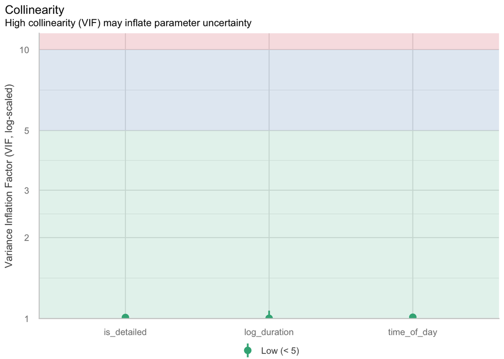

```r
# VIF Check
check_collinearity(model) %>%
  plot() %>%
  print()
```

```r
# Model performance metrics

model_performance(model) %>% knitr::kable(digits = 3, caption = "Model Performance Metrics")
```

Model Performance Metrics

| AIC | AICc | BIC | R2_Tjur | RMSE | Sigma | Log_loss | Score_log | Score_spherical | PCP |
| --- | --- | --- | --- | --- | --- | --- | --- | --- | --- |
| 6631.96 | 6631.962 | 6686.65 | 0.003 | 0.094 | 1 | 0.049 | -5.341 | 0.002 | 0.982 |

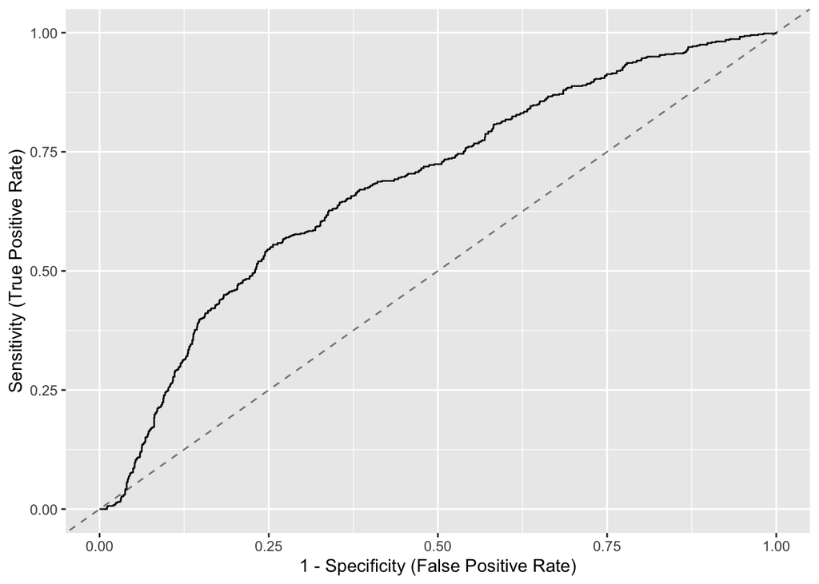

```r
# ROC Curve
performance_roc(model) %>%
  plot()
```

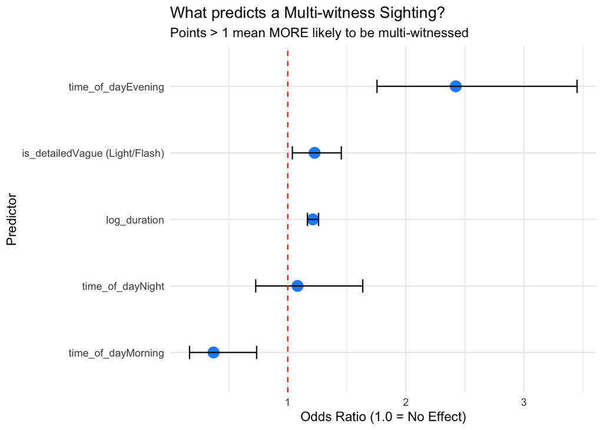

```r
results <- tidy(model, exponentiate = TRUE, conf.int = TRUE) %>%
  filter(term != "(Intercept)")

# Plot
ggplot(results, aes(x = reorder(term, estimate), y = estimate)) +
  geom_point(size = 4, color = "dodgerblue") +
  geom_errorbar(aes(ymin = conf.low, ymax = conf.high), width = 0.2) +
  geom_hline(yintercept = 1, linetype = "dashed", color = "red") +
  coord_flip() +
  labs(
    title = "What predicts a Multi-witness Sighting?",
    subtitle = "Points > 1 mean MORE likely to be multi-witnessed",
    y = "Odds Ratio (1.0 = No Effect)",
    x = "Predictor"
  ) +
  theme_minimal()
```